# Final Clapping Section: Visual Summary

2026-11-24

## Data at a glance

The motion files contain 50 Hz accelerometer-derived signals for 77 participant sensors. 59 participants have defined start/end times and durations in the supplied statistics table. The remaining 18 participants have no defined clapping interval and are not included in timing summaries.

The supplied notes describe sensor time alignment as accurate to approximately 100 ms on average, and stage-event times as accurate to within about half a second. Treat short timing differences cautiously.

## Timeline and ensemble activity

The heatmap shows the trimmed motion series, with participants ordered by their detected clapping start time. Red vertical lines mark stage events. A missing/blank region means no retained observation, not zero motion.

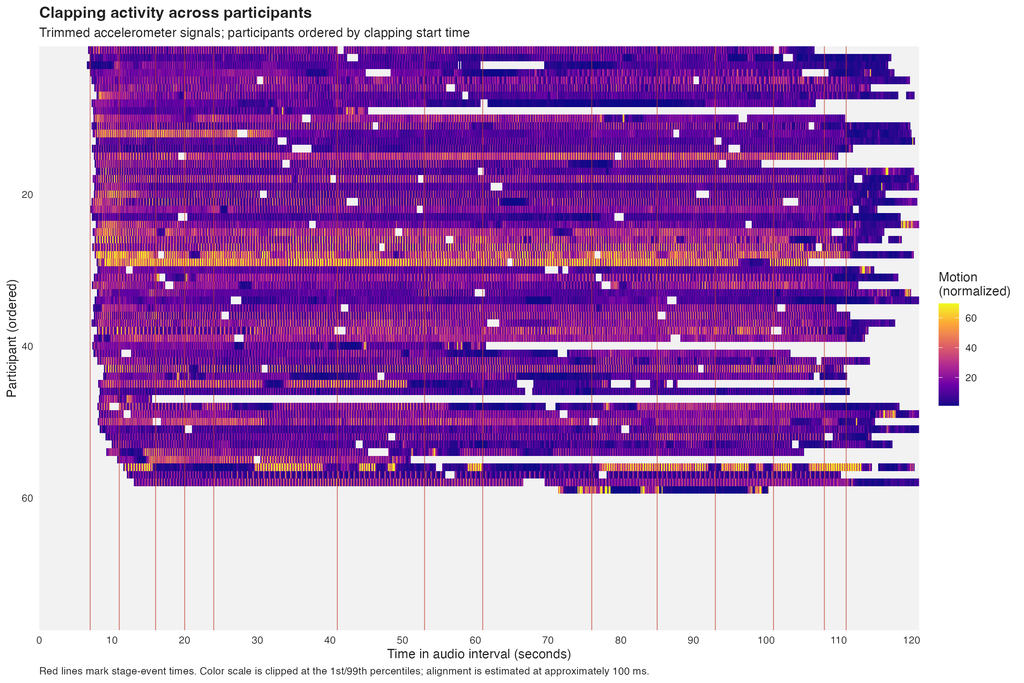

The line below summarizes the median normalized motion across participants at each time point; the shaded band is the interquartile range. These are descriptive summaries, not confidence intervals.

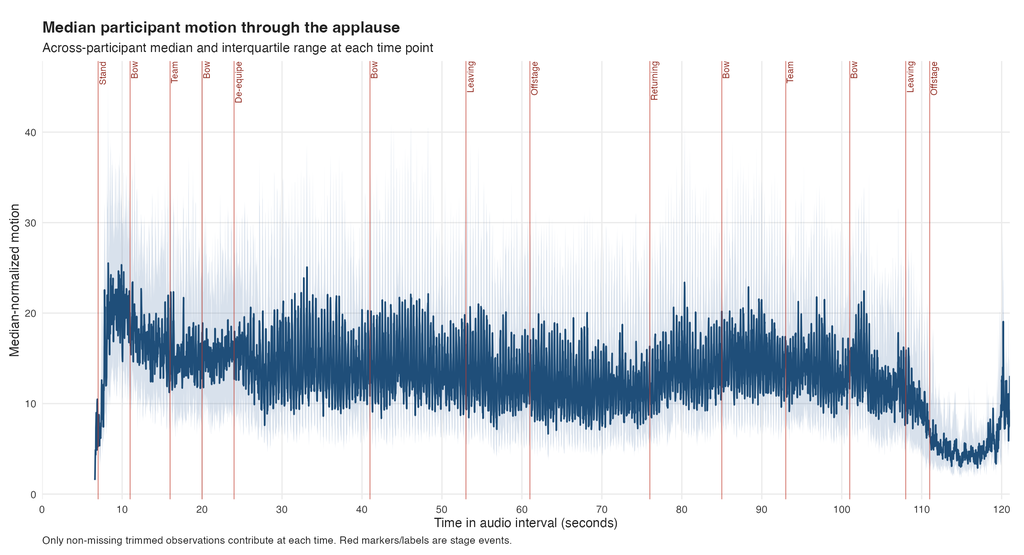

## Participant timing statistics

Descriptive statistics for supplied participant-level measures

| metric | n | mean | median | sd | q1 | q3 | min | max |
| --- | --- | --- | --- | --- | --- | --- | --- | --- |
| Clapping duration (seconds) | 59 | 100.59 | 106.94 | 21.93 | 102.29 | 111.59 | 7.26 | 113.64 |
| Median interclap interval (seconds) | 59 | 0.36 | 0.34 | 0.10 | 0.34 | 0.36 | 0.32 | 1.02 |
| Median interclap rate (claps/minute) | 59 | 170.89 | 176.47 | 20.35 | 166.67 | 176.47 | 58.82 | 187.50 |
| Average RMS during clapping | 59 | 20.44 | 19.70 | 8.45 | 13.94 | 24.04 | 9.11 | 54.04 |
| Average RMS entire concert | 77 | 2.45 | 2.45 | 0.47 | 2.06 | 2.85 | 1.50 | 3.64 |

Among participants with defined durations, the median duration was **106.9 seconds** (IQR 102.3–111.6). The median of participant median interclap intervals was **0.34 seconds**, equivalent to approximately **176 claps per minute**. This rate is a reciprocal transformation of the median interval; it is not the average applause rate of the whole crowd.

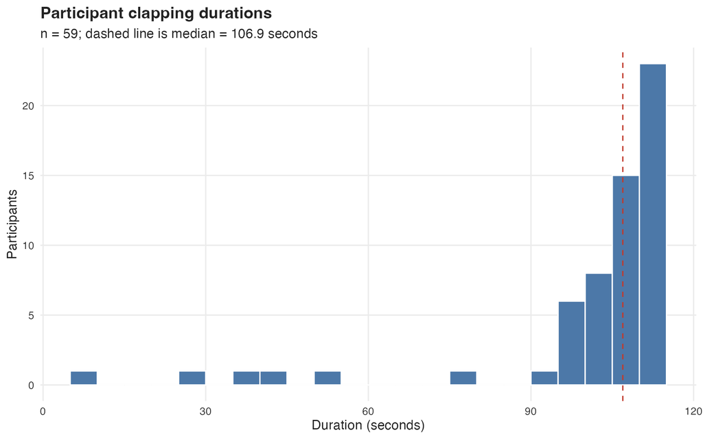

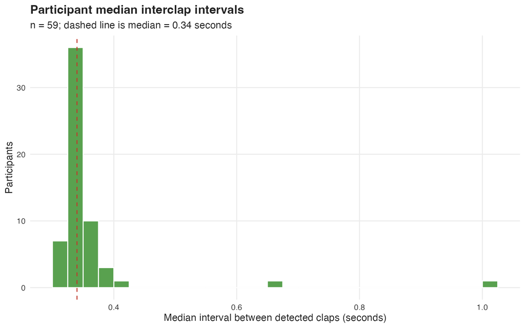

## Exploratory relation between interval and motion

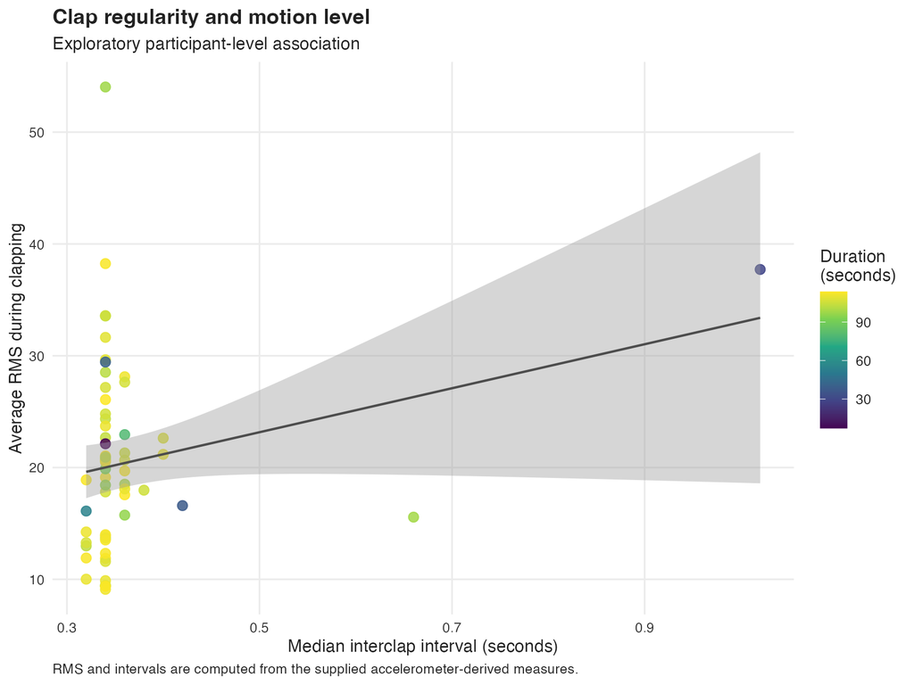

This plot is exploratory and uses participant-level summary measures. Motion values are normalized sensor measures, not calibrated physical acceleration or sound level.

## Stage events

Annotated stage events

| Time (seconds) | Event |
| --- | --- |
| 7 | Stand |
| 11 | Bow |
| 16 | Team |
| 20 | Bow |
| 24 | De-equipe |
| 41 | Bow |
| 53 | Leaving |
| 61 | Offstage |
| 76 | Returning |
| 85 | Bow |
| 93 | Team |
| 101 | Bow |
| 108 | Leaving |
| 111 | Offstage |

## Interpretation cautions

- The data describe clapping by instrumented participants; the concert-hall audio also contains claps from non-participant audience members.
- Signals are median-normalized, so their magnitude should not be read as absolute force or loudness.
- Empty cells are missing observations, and the trimmed data intentionally blank periods outside each participant’s detected clapping interval.
- Participant-level summary distributions describe the instrumented participants only. They are not estimates of audience-wide behavior.
- No inferential tests are included in this visual summary; the data notes do not document a sampling design or population-level model.